# Risk Factor Analysis

## Outcome Variable

**Outcome Variable:** co_occurence

## Predictor Variables

**Intervention Variable:** pers_wasted06

**Adjustment Set:**

- sex
- arm
- brthmon
- single
- hhwealth_quart
- W_mage
- W_mhtcm
- W_meducyrs
- W_feducyrs
- delta_brthmon
- delta_single
- delta_hhwealth_quart
- delta_W_mage
- delta_W_mhtcm
- delta_W_meducyrs
- delta_W_feducyrs

## Stratifying Variables

The analysis was stratified on these variable(s):

- studyid
- country

## Data Summary

| studyid | country | pers_wasted06 | co_occurence | n_cell | n |
| --- | --- | --- | --- | --- | --- |
| ki0047075b-MAL-ED | BANGLADESH | 0 | 0 | 202 | 221 |
| ki0047075b-MAL-ED | BANGLADESH | 0 | 1 | 13 | 221 |
| ki0047075b-MAL-ED | BANGLADESH | 1 | 0 | 5 | 221 |
| ki0047075b-MAL-ED | BANGLADESH | 1 | 1 | 1 | 221 |
| ki0047075b-MAL-ED | BRAZIL | 0 | 0 | 178 | 180 |
| ki0047075b-MAL-ED | BRAZIL | 0 | 1 | 1 | 180 |
| ki0047075b-MAL-ED | BRAZIL | 1 | 0 | 1 | 180 |
| ki0047075b-MAL-ED | BRAZIL | 1 | 1 | 0 | 180 |
| ki0047075b-MAL-ED | INDIA | 0 | 0 | 200 | 228 |
| ki0047075b-MAL-ED | INDIA | 0 | 1 | 13 | 228 |
| ki0047075b-MAL-ED | INDIA | 1 | 0 | 11 | 228 |
| ki0047075b-MAL-ED | INDIA | 1 | 1 | 4 | 228 |
| ki0047075b-MAL-ED | NEPAL | 0 | 0 | 222 | 229 |
| ki0047075b-MAL-ED | NEPAL | 0 | 1 | 4 | 229 |
| ki0047075b-MAL-ED | NEPAL | 1 | 0 | 3 | 229 |
| ki0047075b-MAL-ED | NEPAL | 1 | 1 | 0 | 229 |
| ki0047075b-MAL-ED | PERU | 0 | 0 | 216 | 222 |
| ki0047075b-MAL-ED | PERU | 0 | 1 | 6 | 222 |
| ki0047075b-MAL-ED | PERU | 1 | 0 | 0 | 222 |
| ki0047075b-MAL-ED | PERU | 1 | 1 | 0 | 222 |
| ki0047075b-MAL-ED | SOUTH AFRICA | 0 | 0 | 235 | 241 |
| ki0047075b-MAL-ED | SOUTH AFRICA | 0 | 1 | 3 | 241 |
| ki0047075b-MAL-ED | SOUTH AFRICA | 1 | 0 | 2 | 241 |
| ki0047075b-MAL-ED | SOUTH AFRICA | 1 | 1 | 1 | 241 |
| ki0047075b-MAL-ED | TANZANIA, UNITED REPUBLIC OF | 0 | 0 | 224 | 225 |
| ki0047075b-MAL-ED | TANZANIA, UNITED REPUBLIC OF | 0 | 1 | 1 | 225 |
| ki0047075b-MAL-ED | TANZANIA, UNITED REPUBLIC OF | 1 | 0 | 0 | 225 |
| ki0047075b-MAL-ED | TANZANIA, UNITED REPUBLIC OF | 1 | 1 | 0 | 225 |
| ki1000108-CMC-V-BCS-2002 | INDIA | 0 | 0 | 308 | 366 |
| ki1000108-CMC-V-BCS-2002 | INDIA | 0 | 1 | 7 | 366 |

[output cut: 78 more lines]

The following strata were considered:

- studyid: ki0047075b-MAL-ED, country: BANGLADESH
- studyid: ki0047075b-MAL-ED, country: BRAZIL
- studyid: ki0047075b-MAL-ED, country: INDIA
- studyid: ki0047075b-MAL-ED, country: NEPAL
- studyid: ki0047075b-MAL-ED, country: PERU
- studyid: ki0047075b-MAL-ED, country: SOUTH AFRICA
- studyid: ki0047075b-MAL-ED, country: TANZANIA, UNITED REPUBLIC OF
- studyid: ki1000108-CMC-V-BCS-2002, country: INDIA
- studyid: ki1000108-IRC, country: INDIA
- studyid: ki1000109-EE, country: PAKISTAN
- studyid: ki1000109-ResPak, country: PAKISTAN
- studyid: ki1000304b-SAS-CompFeed, country: INDIA
- studyid: ki1000304b-SAS-FoodSuppl, country: INDIA
- studyid: ki1017093-NIH-Birth, country: BANGLADESH
- studyid: ki1017093b-PROVIDE, country: BANGLADESH
- studyid: ki1017093c-NIH-Crypto, country: BANGLADESH
- studyid: ki1066203-TanzaniaChild2, country: TANZANIA, UNITED REPUBLIC OF
- studyid: ki1101329-Keneba, country: GAMBIA
- studyid: ki1113344-GMS-Nepal, country: NEPAL
- studyid: ki1114097-CMIN, country: BANGLADESH
- studyid: ki1114097-CONTENT, country: PERU
- studyid: ki1119695-PROBIT, country: BELARUS
- studyid: ki1126311-ZVITAMBO, country: ZIMBABWE
- studyid: ki1135781-COHORTS, country: GUATEMALA
- studyid: ki1135781-COHORTS, country: PHILIPPINES
- studyid: ki1148112-LCNI-5, country: MALAWI
- studyid: kiGH5241-JiVitA-4, country: BANGLADESH

### Dropped Strata

Some strata were dropped due to rare outcomes:

- studyid: ki0047075b-MAL-ED, country: BANGLADESH
- studyid: ki0047075b-MAL-ED, country: BRAZIL
- studyid: ki0047075b-MAL-ED, country: INDIA
- studyid: ki0047075b-MAL-ED, country: NEPAL
- studyid: ki0047075b-MAL-ED, country: PERU
- studyid: ki0047075b-MAL-ED, country: SOUTH AFRICA
- studyid: ki0047075b-MAL-ED, country: TANZANIA, UNITED REPUBLIC OF
- studyid: ki1000108-IRC, country: INDIA
- studyid: ki1000109-ResPak, country: PAKISTAN
- studyid: ki1017093b-PROVIDE, country: BANGLADESH
- studyid: ki1066203-TanzaniaChild2, country: TANZANIA, UNITED REPUBLIC OF
- studyid: ki1114097-CMIN, country: BANGLADESH
- studyid: ki1114097-CONTENT, country: PERU
- studyid: ki1119695-PROBIT, country: BELARUS
- studyid: ki1148112-LCNI-5, country: MALAWI

## Methods Detail

We’re interested in the causal parameters $E[Y_a]$ for all values of $a \in \mathcal{A}$. These parameters represent the mean outcome if, possibly contrary to fact, we intervened to set all units to have $A=a$. Under the randomization and positivity assumptions, these are identified by the statistical parameters $\psi_a=E_W[E_{Y|A,W}(Y|A=a,W)]$. In addition, we’re interested in the mean of $Y$, $E[Y]$ under no intervention (the observed mean). We will estimate these parameters by using SuperLearner to fit the relevant likelihood factors – $E_{Y|A,W}(Y|A=a,W)$ and $p(A=a|W)$, and then updating our likelihood fit using a joint TMLE.

For unadjusted analyses ($W=\{\}$), initial likelihoods were estimated using Lrnr_glm to estimate the simple $E(Y|A)$ and Lrnr_mean to estimate $p(A)$. For adjusted analyses, a small library containing Lrnr_glmnet, Lrnr_xgboost, and Lrnr_mean was used.

Having estimated these parameters, we will then use the delta method to estimate relative risks and attributable risks relative to a prespecified baseline level of $A$.

# Results Detail

## Results Plots

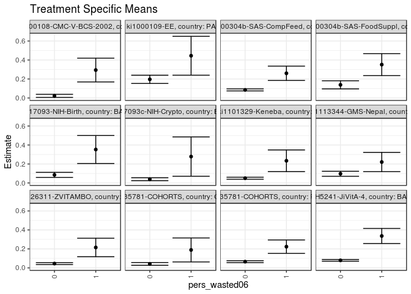

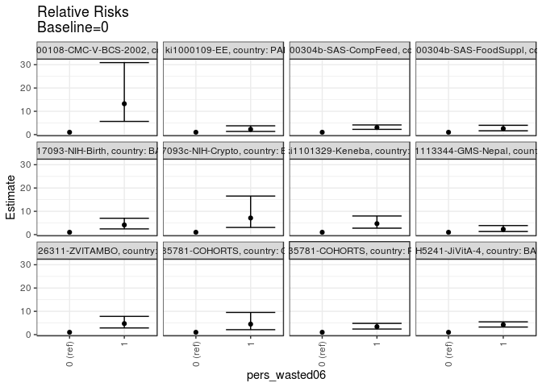

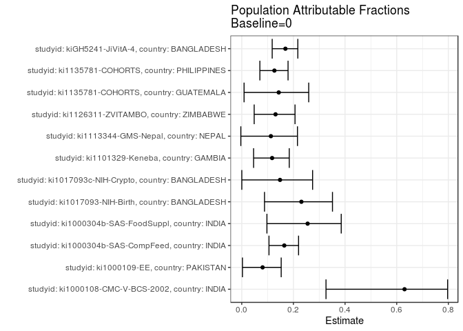

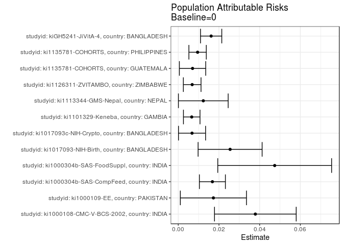

## Results Table

### Parameter: TSM

| studyid | country | intervention_level | baseline_level | estimate | ci_lower | ci_upper |
| --- | --- | --- | --- | --- | --- | --- |
| ki1000108-CMC-V-BCS-2002 | INDIA | 0 | NA | 0.0222222 | 0.0059217 | 0.0385227 |
| ki1000108-CMC-V-BCS-2002 | INDIA | 1 | NA | 0.2941176 | 0.1688947 | 0.4193406 |
| ki1000109-EE | PAKISTAN | 0 | NA | 0.1965967 | 0.1530347 | 0.2401588 |
| ki1000109-EE | PAKISTAN | 1 | NA | 0.4450045 | 0.2403782 | 0.6496307 |
| ki1000304b-SAS-CompFeed | INDIA | 0 | NA | 0.0851274 | 0.0744427 | 0.0958120 |
| ki1000304b-SAS-CompFeed | INDIA | 1 | NA | 0.2599961 | 0.1845789 | 0.3354133 |
| ki1000304b-SAS-FoodSuppl | INDIA | 0 | NA | 0.1383723 | 0.0956428 | 0.1811018 |
| ki1000304b-SAS-FoodSuppl | INDIA | 1 | NA | 0.3515124 | 0.2358179 | 0.4672068 |
| ki1017093-NIH-Birth | BANGLADESH | 0 | NA | 0.0849007 | 0.0582484 | 0.1115530 |
| ki1017093-NIH-Birth | BANGLADESH | 1 | NA | 0.3521685 | 0.2044247 | 0.4999122 |
| ki1017093c-NIH-Crypto | BANGLADESH | 0 | NA | 0.0389610 | 0.0236683 | 0.0542538 |
| ki1017093c-NIH-Crypto | BANGLADESH | 1 | NA | 0.2777778 | 0.0706975 | 0.4848581 |
| ki1101329-Keneba | GAMBIA | 0 | NA | 0.0497113 | 0.0394172 | 0.0600054 |
| ki1101329-Keneba | GAMBIA | 1 | NA | 0.2334963 | 0.1192877 | 0.3477050 |
| ki1113344-GMS-Nepal | NEPAL | 0 | NA | 0.0967806 | 0.0705163 | 0.1230448 |
| ki1113344-GMS-Nepal | NEPAL | 1 | NA | 0.2204186 | 0.1190055 | 0.3218317 |
| ki1126311-ZVITAMBO | ZIMBABWE | 0 | NA | 0.0455289 | 0.0353212 | 0.0557367 |
| ki1126311-ZVITAMBO | ZIMBABWE | 1 | NA | 0.2154345 | 0.1178933 | 0.3129756 |
| ki1135781-COHORTS | GUATEMALA | 0 | NA | 0.0420624 | 0.0275610 | 0.0565638 |
| ki1135781-COHORTS | GUATEMALA | 1 | NA | 0.1891892 | 0.0629088 | 0.3154696 |
| ki1135781-COHORTS | PHILIPPINES | 0 | NA | 0.0656838 | 0.0556611 | 0.0757066 |
| ki1135781-COHORTS | PHILIPPINES | 1 | NA | 0.2238502 | 0.1532840 | 0.2944164 |
| kiGH5241-JiVitA-4 | BANGLADESH | 0 | NA | 0.0794802 | 0.0703755 | 0.0885848 |
| kiGH5241-JiVitA-4 | BANGLADESH | 1 | NA | 0.3363348 | 0.2567754 | 0.4158942 |

### Parameter: E(Y)

| studyid | country | intervention_level | baseline_level | estimate | ci_lower | ci_upper |
| --- | --- | --- | --- | --- | --- | --- |
| ki1000108-CMC-V-BCS-2002 | INDIA | NA | NA | 0.0601093 | 0.0357249 | 0.0844936 |
| ki1000109-EE | PAKISTAN | NA | NA | 0.2138728 | 0.1706052 | 0.2571404 |
| ki1000304b-SAS-CompFeed | INDIA | NA | NA | 0.1019108 | 0.0902026 | 0.1136190 |
| ki1000304b-SAS-FoodSuppl | INDIA | NA | NA | 0.1857585 | 0.1432798 | 0.2282372 |
| ki1017093-NIH-Birth | BANGLADESH | NA | NA | 0.1103896 | 0.0817833 | 0.1389959 |
| ki1017093c-NIH-Crypto | BANGLADESH | NA | NA | 0.0457413 | 0.0294659 | 0.0620168 |
| ki1101329-Keneba | GAMBIA | NA | NA | 0.0563380 | 0.0456085 | 0.0670676 |
| ki1113344-GMS-Nepal | NEPAL | NA | NA | 0.1090909 | 0.0830130 | 0.1351688 |
| ki1126311-ZVITAMBO | ZIMBABWE | NA | NA | 0.0523810 | 0.0417242 | 0.0630377 |
| ki1135781-COHORTS | GUATEMALA | NA | NA | 0.0490956 | 0.0338639 | 0.0643273 |
| ki1135781-COHORTS | PHILIPPINES | NA | NA | 0.0751910 | 0.0648251 | 0.0855569 |
| kiGH5241-JiVitA-4 | BANGLADESH | NA | NA | 0.0956483 | 0.0855904 | 0.1057063 |

### Parameter: RR

| studyid | country | intervention_level | baseline_level | estimate | ci_lower | ci_upper |
| --- | --- | --- | --- | --- | --- | --- |
| ki1000108-CMC-V-BCS-2002 | INDIA | 0 | 0 | 1.000000 | 1.000000 | 1.000000 |
| ki1000108-CMC-V-BCS-2002 | INDIA | 1 | 0 | 13.235294 | 5.667550 | 30.908064 |
| ki1000109-EE | PAKISTAN | 0 | 0 | 1.000000 | 1.000000 | 1.000000 |
| ki1000109-EE | PAKISTAN | 1 | 0 | 2.263540 | 1.355497 | 3.779876 |
| ki1000304b-SAS-CompFeed | INDIA | 0 | 0 | 1.000000 | 1.000000 | 1.000000 |
| ki1000304b-SAS-CompFeed | INDIA | 1 | 0 | 3.054201 | 2.255374 | 4.135963 |
| ki1000304b-SAS-FoodSuppl | INDIA | 0 | 0 | 1.000000 | 1.000000 | 1.000000 |
| ki1000304b-SAS-FoodSuppl | INDIA | 1 | 0 | 2.540337 | 1.616538 | 3.992058 |
| ki1017093-NIH-Birth | BANGLADESH | 0 | 0 | 1.000000 | 1.000000 | 1.000000 |
| ki1017093-NIH-Birth | BANGLADESH | 1 | 0 | 4.148005 | 2.450729 | 7.020745 |
| ki1017093c-NIH-Crypto | BANGLADESH | 0 | 0 | 1.000000 | 1.000000 | 1.000000 |
| ki1017093c-NIH-Crypto | BANGLADESH | 1 | 0 | 7.129630 | 3.070223 | 16.556328 |
| ki1101329-Keneba | GAMBIA | 0 | 0 | 1.000000 | 1.000000 | 1.000000 |
| ki1101329-Keneba | GAMBIA | 1 | 0 | 4.697047 | 2.762206 | 7.987186 |
| ki1113344-GMS-Nepal | NEPAL | 0 | 0 | 1.000000 | 1.000000 | 1.000000 |
| ki1113344-GMS-Nepal | NEPAL | 1 | 0 | 2.277509 | 1.334648 | 3.886453 |
| ki1126311-ZVITAMBO | ZIMBABWE | 0 | 0 | 1.000000 | 1.000000 | 1.000000 |
| ki1126311-ZVITAMBO | ZIMBABWE | 1 | 0 | 4.731816 | 2.854753 | 7.843089 |
| ki1135781-COHORTS | GUATEMALA | 0 | 0 | 1.000000 | 1.000000 | 1.000000 |
| ki1135781-COHORTS | GUATEMALA | 1 | 0 | 4.497820 | 2.121945 | 9.533891 |
| ki1135781-COHORTS | PHILIPPINES | 0 | 0 | 1.000000 | 1.000000 | 1.000000 |
| ki1135781-COHORTS | PHILIPPINES | 1 | 0 | 3.407995 | 2.401813 | 4.835693 |
| kiGH5241-JiVitA-4 | BANGLADESH | 0 | 0 | 1.000000 | 1.000000 | 1.000000 |
| kiGH5241-JiVitA-4 | BANGLADESH | 1 | 0 | 4.231681 | 3.260002 | 5.492980 |

### Parameter: PAR

| studyid | country | intervention_level | baseline_level | estimate | ci_lower | ci_upper |
| --- | --- | --- | --- | --- | --- | --- |
| ki1000108-CMC-V-BCS-2002 | INDIA | 0 | NA | 0.0378871 | 0.0178137 | 0.0579604 |
| ki1000109-EE | PAKISTAN | 0 | NA | 0.0172761 | 0.0010298 | 0.0335225 |
| ki1000304b-SAS-CompFeed | INDIA | 0 | NA | 0.0167835 | 0.0103961 | 0.0231708 |
| ki1000304b-SAS-FoodSuppl | INDIA | 0 | NA | 0.0473862 | 0.0194154 | 0.0753570 |
| ki1017093-NIH-Birth | BANGLADESH | 0 | NA | 0.0254889 | 0.0097601 | 0.0412177 |
| ki1017093c-NIH-Crypto | BANGLADESH | 0 | NA | 0.0067803 | 0.0001243 | 0.0134362 |
| ki1101329-Keneba | GAMBIA | 0 | NA | 0.0066267 | 0.0025620 | 0.0106915 |
| ki1113344-GMS-Nepal | NEPAL | 0 | NA | 0.0123104 | 0.0000866 | 0.0245341 |
| ki1126311-ZVITAMBO | ZIMBABWE | 0 | NA | 0.0068520 | 0.0025114 | 0.0111927 |
| ki1135781-COHORTS | GUATEMALA | 0 | NA | 0.0070332 | 0.0005665 | 0.0134999 |
| ki1135781-COHORTS | PHILIPPINES | 0 | NA | 0.0095071 | 0.0052315 | 0.0137828 |
| kiGH5241-JiVitA-4 | BANGLADESH | 0 | NA | 0.0161682 | 0.0109405 | 0.0213958 |

### Parameter: PAF

| studyid | country | intervention_level | baseline_level | estimate | ci_lower | ci_upper |
| --- | --- | --- | --- | --- | --- | --- |
| ki1000108-CMC-V-BCS-2002 | INDIA | 0 | NA | 0.6303030 | 0.3262436 | 0.7971435 |
| ki1000109-EE | PAKISTAN | 0 | NA | 0.0807776 | 0.0026950 | 0.1527467 |
| ki1000304b-SAS-CompFeed | INDIA | 0 | NA | 0.1646877 | 0.1054461 | 0.2200060 |
| ki1000304b-SAS-FoodSuppl | INDIA | 0 | NA | 0.2550957 | 0.0974422 | 0.3852113 |
| ki1017093-NIH-Birth | BANGLADESH | 0 | NA | 0.2308997 | 0.0881386 | 0.3513101 |
| ki1017093c-NIH-Crypto | BANGLADESH | 0 | NA | 0.1482311 | 0.0002406 | 0.2743151 |
| ki1101329-Keneba | GAMBIA | 0 | NA | 0.1176244 | 0.0458960 | 0.1839604 |
| ki1113344-GMS-Nepal | NEPAL | 0 | NA | 0.1128449 | -0.0035371 | 0.2157299 |
| ki1126311-ZVITAMBO | ZIMBABWE | 0 | NA | 0.1308115 | 0.0481841 | 0.2062660 |
| ki1135781-COHORTS | GUATEMALA | 0 | NA | 0.1432550 | 0.0090294 | 0.2593000 |
| ki1135781-COHORTS | PHILIPPINES | 0 | NA | 0.1264400 | 0.0701860 | 0.1792906 |
| kiGH5241-JiVitA-4 | BANGLADESH | 0 | NA | 0.1690375 | 0.1179223 | 0.2171906 |